# Build a Model

Os dados em sim1 são dados simulados e vamos iniciar olhando os dados através de um “scatterplot”.

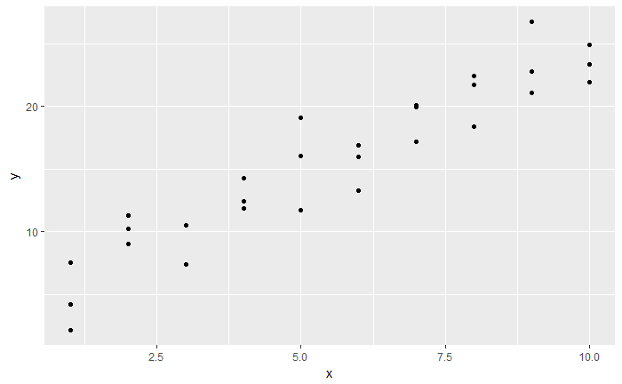

```r
ggplot(sim1, aes(x = x, y = y)) + geom_point()
```

Podemos observar que há um forte relacionamento linear entre as varáveis “x” e “y”. Vamos tentar capturar este relacionamento linear. Inicialmente vamos gerar 250 modelos diferente aleatórios e plotar todos os modelos por cima dos nossos dados. Para plotar todos os modelos vamos usar geom_abline passando a interseção e a inclinação.

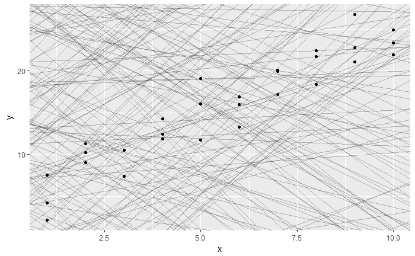

```r
models = tibble (
  a1 = runif(250, -20, 40),
  a2 = runif(250, -5, 5)
)
ggplot(sim1, aes(x = x, y = y)) +
  geom_abline(aes(intercept = a1, slope = a2),
              data = models, alpha = 1/4) +
  geom_point()
```

```r
# Função model1 pega o valor de x de 'data' e calcula o valor de y corresponde no modelo
model1 = function(a, data) {
  a[1] + data$x * a[2]
}
# exemplo de como chamar a função model1, passando os valores de interseção e coeficiente
model1(c(7, 1.5), sim1)
```

```
 [1]  8.5  8.5  8.5 10.0 10.0 10.0 11.5 11.5 11.5 13.0 13.0 13.0 14.5 14.5 14.5 16.0 16.0 16.0 17.5 17.5
[21] 17.5 19.0 19.0 19.0 20.5 20.5 20.5 22.0 22.0 22.0
```

```r
measure_distance = function(mod, data) {
  diff = data$y - model1(mod, data)
  sqrt(mean(diff ^ 2))
}
measure_distance(c(7,1.5), sim1)
```

```
[1] 2.665212
```

```r
# mede a distância entre um modelo dados por interseção e coeficiente para os dados em sim1
sim1_dist = function(intersept, slope) {
  measure_distance(c(intersept, slope), sim1)
}
# verifica a distância de todos os modelos criados para os dados em sim1
models = models %>%
  mutate(dist = purrr::map2_dbl(a1, a2, sim1_dist))
models
```

| a1 | a2 | dist |
| --- | --- | --- |
| 27.09707735 | 4.225855379 | 35.454360 |
| 11.51177491 | 2.053741673 | 7.606870 |
| 7.44103642 | 4.727706122 | 19.632334 |
| 8.47867429 | 4.415005934 | 18.665908 |
| -1.26241444 | 1.610628990 | 8.286899 |
| 26.70342776 | -2.432587296 | 13.235079 |
| 29.40137295 | -3.270156013 | 15.965276 |
| -3.91862486 | -1.990391547 | 32.582964 |
| -13.50072852 | 1.929411402 | 18.519253 |
| 34.95823646 | 4.128614939 | 42.634523 |

[output cut: 240 more lines]

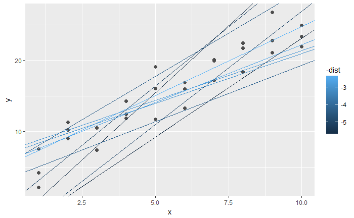

```r
ggplot(sim1, aes(x, y)) +
  # colocar os pontos dos dados com tamanho 2 e cor especificada
  geom_point(size = 2, color = "grey30") +
  # adicionar as 10 primeiras ablines
  geom_abline(aes(intercept = a1, slope = a2, color = -dist),
              data = filter(models, rank(dist) <= 10))
```

Vamos fazer um grid de pontos em vez de gerar os pontos do modelo aleatoriamente e plotar os 10 melhores modelos.

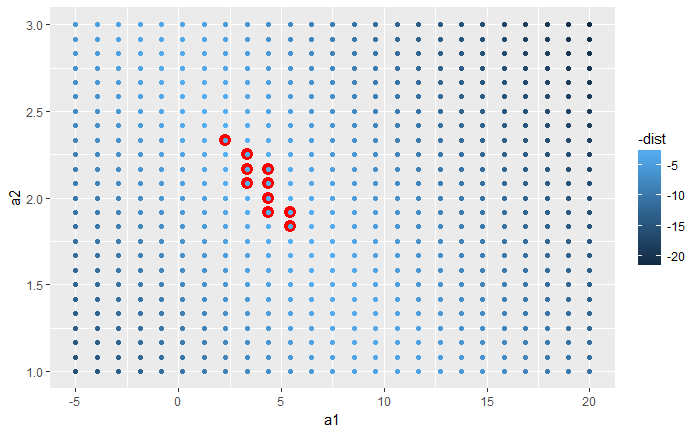

```r
grid = expand.grid(
  a1 = seq(-5, 20, length = 25),
  a2 = seq(1, 3, length = 25)
) %>%
  mutate(dist = purrr::map2_dbl(a1, a2, sim1_dist))
grid %>%
  ggplot(aes(a1, a2)) +
  geom_point(data = filter(grid, rank(dist) <= 10),
             color = "red", size = 4) +
  geom_point(aes(color = -dist))
```

Agora vamos sobrepor os 10 melhores modelos em cima dos dados originais

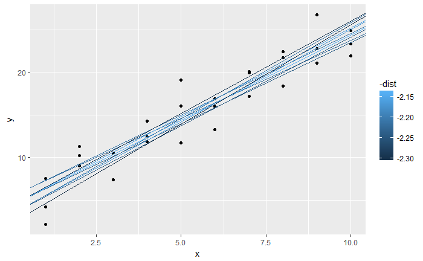

```r
ggplot(sim1, aes(x, y)) +
  geom_point() +
  geom_abline(data = filter(grid, rank(dist) <= 10),
              aes(intercept = a1, slope = a2, color = -dist))
```

Utilizando a função lm do base R para encontrar o melhor modelo linear para estes pontos

```r
sim1_lm_fit = lm(y ~ x, data = sim1)
coef(sim1_lm_fit)
```

```
(Intercept)           x
   4.220822    2.051533
```

Vamos plotar este modelo em cima dos dados

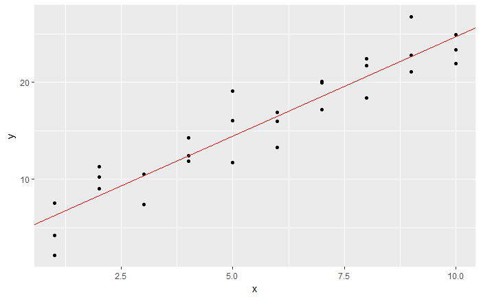

```r
sim1 %>%
  ggplot(aes(x, y)) + geom_point() +
  geom_abline(intercept = coef(sim1_lm_fit)[[1]],
              slope = coef(sim1_lm_fit)[[2]], color = "red")
```

# Visualizando um Modelo

Até o presente momento, utilizamos geom_abline para visualizar o resultado de nossa previsão. Esta solução é bastante simples e limitada a modelos lineares que podem ser facilmente visualizados. Vamos agora utilizar uma metodologia mais genérica que se aplica a qualquer modelo, não somente a modelos lineares.

Inicialmente cria-se uma grade para inserção dos dados da previsão

```r
grid = sim1 %>% data_grid(x)
grid
```

| x |
| --- |
| 1 |
| 2 |
| 3 |
| 4 |
| 5 |
| 6 |
| 7 |
| 8 |
| 9 |
| 10 |

Agora adicionamos à grade os valores obtidos na previsão

```r
grid = grid %>% add_predictions(sim1_lm_fit)
grid
```

| x | pred |
| --- | --- |
| 1 | 6.272355 |
| 2 | 8.323888 |
| 3 | 10.375421 |
| 4 | 12.426954 |
| 5 | 14.478487 |
| 6 | 16.530020 |
| 7 | 18.581553 |
| 8 | 20.633087 |
| 9 | 22.684620 |
| 10 | 24.736153 |

E finalmente, podemos visualizar o resultado do modelo através de um gráfico. Neste momento, o gráfico é o mesmo já obtido anteriormente através do geom_abline. Veremos adiante que esta metodologia é mais genérica

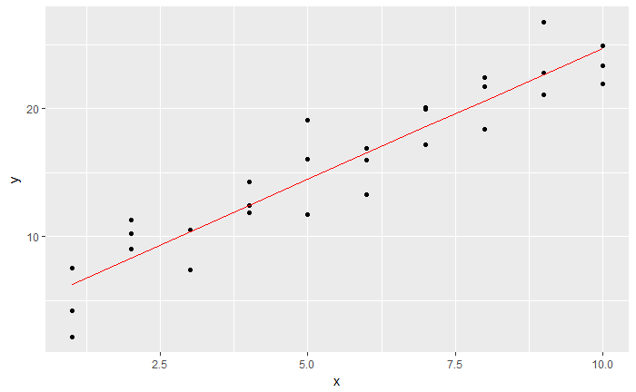

```r
sim1 %>%
  ggplot(aes(x, y)) + geom_point() +
  geom_line(data = grid, aes(y = pred), color = "red")
```

## Residuais

Dando continuidade à visualização do modelo, vamos agora analisar os dados residuais. Os residuais são o “erro” não capturado pelo modelo, dado, neste modelo, pela distância dos pontos estimados até os pontos reais. Neste caso, os residuais são adicionados aos dados originais e não na grade, pois para adicionar os residuais é necessário ter a informação dos dados reais

```r
sim1 = sim1 %>%
  add_residuals(sim1_lm_fit)
sim1
```

| x | y | resid |
| --- | --- | --- |
| 1 | 4.199913 | -2.072442018 |
| 1 | 7.510634 | 1.238279125 |
| 1 | 2.125473 | -4.146882207 |
| 2 | 8.988857 | 0.664969362 |
| 2 | 10.243105 | 1.919217378 |
| 2 | 11.296823 | 2.972935148 |
| 3 | 7.356365 | -3.019056466 |
| 3 | 10.505349 | 0.129928252 |
| 3 | 10.511601 | 0.136179642 |
| 4 | 12.434589 | 0.007634878 |

[output cut: 20 more lines]

Vamos verificar as frequências do residual

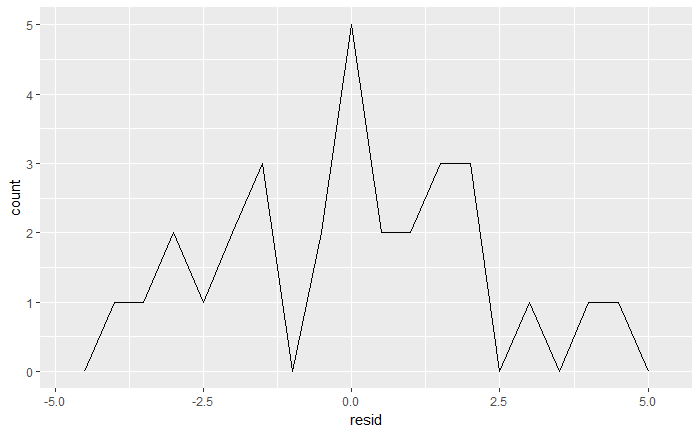

```r
sim1 %>%
  ggplot(aes(resid)) + geom_freqpoly(binwidth = 0.5)
```

```r
NA
```

Vamos agora plotar o grpafico do residual no lugar do valor de y, ou seja, estamos olhando o gráfico das previsões “sem a tendência” calculada pelo modelo

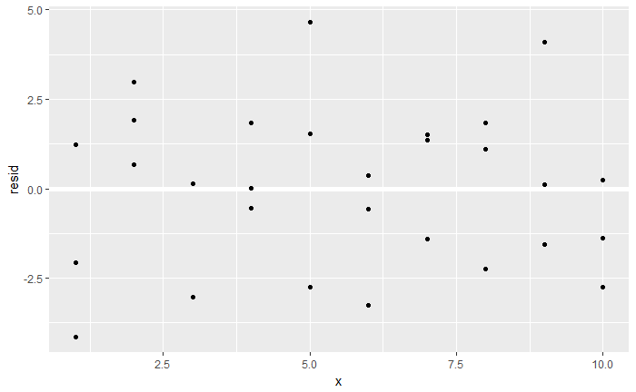

```r
sim1 %>%
  ggplot(aes(x, resid)) +
  geom_ref_line(h = 0) +
  geom_point()
```

Observamos que os residuais paracem distribuidos aleatoriamente, o que indica que a previsão feita anteriormente captura a maioria da tendência.

## Formulas

[output not shown]

Vamos fazer as mesmas etapas feitas anteriormente agora com outro modelo que contém variáveis de categoria.

```r
sim2
```

| x | y |
| --- | --- |
| a | 1.9353632 |
| a | 1.1764886 |
| a | 1.2436855 |
| a | 2.6235489 |
| a | 1.1120381 |
| a | 0.8660030 |
| a | -0.9100875 |
| a | 0.7207628 |
| a | 0.6865540 |
| a | 2.0673079 |

[output cut: 30 more lines]

```r
sim2_lm_fit = lm(y ~ x, data = sim2)
```

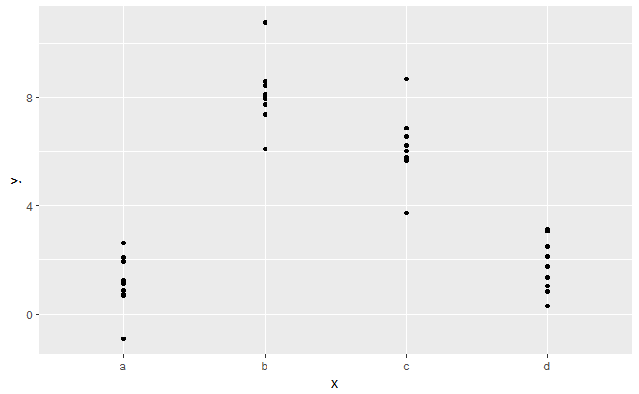

```r
sim2 %>%
  ggplot(aes(x, y)) + geom_point()
```

```r
grid2 = sim2 %>% data_grid(x)
grid2 = grid2 %>% add_predictions(sim2_lm_fit)
grid2
```

| x | pred |
| --- | --- |
| a | 1.152166 |
| b | 8.116039 |
| c | 6.127191 |
| d | 1.910981 |

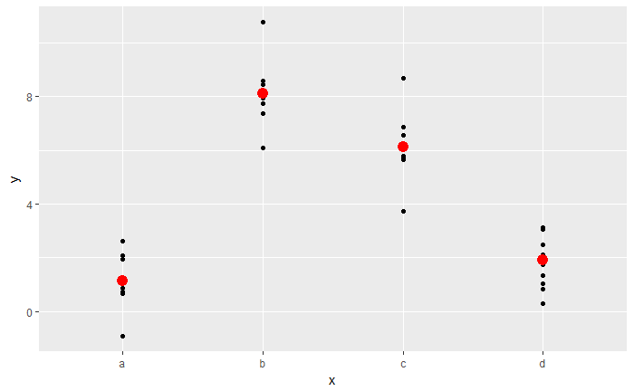

```r
sim2 %>%
  ggplot(aes(x, y)) + geom_point() +
  geom_point(data = grid2, aes(y = pred), color = "red", size = 4)
```

Vamos verificar um terceiro modelo

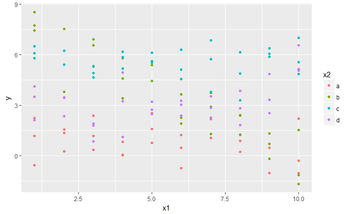

```r
sim3 %>% ggplot(aes(x1, y)) + geom_point(aes(color = x2))
```

```r
sim3_lm_fit1 = lm(data = sim3, y ~ x1 + x2)
sim3_lm_fit1
```

```
Call:
lm(formula = y ~ x1 + x2, data = sim3)

Coefficients:
(Intercept)           x1          x2b          x2c          x2d
     1.8717      -0.1967       2.8878       4.8057       2.3596
```

```r
sim3_lm_fit2 = lm(data = sim3, y ~ x1 * x2)
sim3_lm_fit2
```

```
Call:
lm(formula = y ~ x1 * x2, data = sim3)

Coefficients:
(Intercept)           x1          x2b          x2c          x2d       x1:x2b       x1:x2c       x1:x2d
    1.30124     -0.09302      7.06938      4.43090      0.83455     -0.76029      0.06815      0.27728
```

```r
grid3 = sim3 %>% data_grid(x1, x2)
grid3 = grid3 %>% gather_predictions(sim3_lm_fit1, sim3_lm_fit2)
grid3
```

| model | x1 | x2 | pred |
| --- | --- | --- | --- |
| sim3_lm_fit1 | 1 | a | 1.67492811 |
| sim3_lm_fit1 | 1 | b | 4.56273896 |
| sim3_lm_fit1 | 1 | c | 6.48066399 |
| sim3_lm_fit1 | 1 | d | 4.03451486 |
| sim3_lm_fit1 | 2 | a | 1.47819036 |
| sim3_lm_fit1 | 2 | b | 4.36600121 |
| sim3_lm_fit1 | 2 | c | 6.28392624 |
| sim3_lm_fit1 | 2 | d | 3.83777710 |
| sim3_lm_fit1 | 3 | a | 1.28145260 |
| sim3_lm_fit1 | 3 | b | 4.16926345 |

[output cut: 70 more lines]

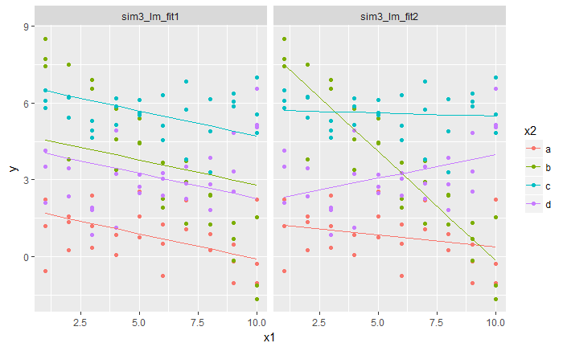

```r
sim3 %>% ggplot(aes(x1, y, color = x2)) + geom_point() +
  geom_line(data = grid3, aes(y = pred)) + facet_wrap(~ model)
```

```r
NA
```

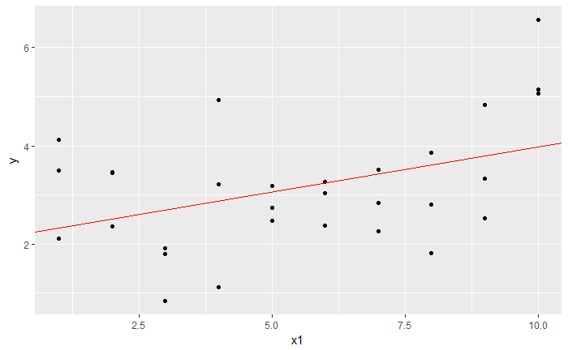

```r
sim3_1 = sim3 %>% filter(x2 == "d")
sim3_1_lm_fit = lm(data = sim3_1, y ~ x1)
sim3_1 %>%
  ggplot(aes(x1, y)) + geom_point() +
  geom_abline(intercept = coef(sim3_1_lm_fit)[[1]],
              slope = coef(sim3_1_lm_fit)[[2]], color = "red")
```

```r
sim3_1_lm_fit
```

```
Call:
lm(formula = y ~ x1, data = sim3_1)

Coefficients:
(Intercept)           x1
     2.1358       0.1843
```